# Homework 8

Tyler Poelking

4/3/2018

Question 1) Provide interpretations for all of the unknown parameters in the model above in the context of the problem.

μij represents the mean change in packed cell volume from each breed j given the ith’s cat dose and type.

σ2 represents the variability of the mean change in packed cell volume about the breed dose and type specific mean.

aj represents the change in the mean change in packed cell volume due to the given breed of the cat.

B1 represents the baseline of the mean change in packed cell volume of secondary erythrocytosis without taking breed and dose into account.

B2 represents the change in mean change in pakced cell value as the dose increases by one.

B3 represents the change in mean change in pakced cell value as the type goes from secondary erythrocytosis to primary erythrocytosis.

γ (gamma) represents the mean of the change in the mean change in packed cell volume of domestic (breed = A,B,or C) cats. Note aj (see interpretation above) has a mean of zero when the cat is non-domestic (breed = D or E).

τ2α represents the variability of the domestic specific change in the mean change in packed cell volume about the domestic specific mean.

Question 2)

```r
cats = read.table("~/Downloads/cats.txt", header=T)

#add domestic column
cats <- transform(cats, Domestic= ifelse(Breed%in% c('A', 'B','C'), 1, 0))
#View(cats)
attach(cats)

n = length(DeltaPCV)

breedNumeric <- as.numeric(Breed)
typeNumeric <- as.numeric(Type)
domestic<-c(1,1,1,0,0)

breedUniq <-length( unique( Breed ) )
typeUniq <-length( unique( Type ) )


# create objects for JAGS
dataList <- list( "DeltaPCV" = DeltaPCV,
                  "breedUniq" = breedUniq,
                  "n" = n,
                  "Dose" = Dose,
                  "Breed" = breedNumeric,
                  "Domestic" = domestic,
                  "Type" = typeNumeric)

# list of parameters to be monitored
parameters <- c( "a",
                 "B1",
                 "B2",
                 "B3",
                 "y",
                 "inv_sigma_2",
                 "inv_tau_2")


# set initial values
initsValues <- list( "a" =rep(0, breedUniq),
                 "B1" = 1,
                 "B2"=1,
                 "B3"=1,
                 "y" = 1,
                 "inv_sigma_2"=.1 ,
                 "inv_tau_2"= .1)

# number of iteration for "tuning"
adaptSteps <- 5000

# number of iterations for "burn-in"
burnInSteps <- 5000

# number of chains to run
nChains <- 2

# total number of iterations to save
numSavedSteps <- 5000

# "thinning" (1 = keep every interation)
thinSteps <- 1

# iterations per chain
ITER <- ceiling( (numSavedSteps * thinSteps) / nChains )

# -------------
# Run JAGS
# -------------

# create, initialize, and adapt the model
jagsModel <- jags.model("~/Desktop/All Stuff/School Stuff/STATS/3303/Homework8/cats_model.txt",
                         data = dataList,
                         inits = initsValues,
                         n.chains = nChains,
                         n.adapt = adaptSteps)
```

```r
# burn-in the algorithm
update( jagsModel,
        n.iter = burnInSteps )

# run algorithm to get interations for inference
codaSamples <- coda.samples( jagsModel,
                             variable.names = parameters,
                             n.iter = ITER,
                             thin = thinSteps )

# -------------
# Look at posterior samples
# -------------

# make a dataframe with the posterior samples
mcmcChainDF <- data.frame( as.matrix( codaSamples,
                                      iters = T,
                                      chains = T ) )

# create a vector with the variable names
varNames <- names( mcmcChainDF )[3:( dim( mcmcChainDF )[2] )]

# number of variables
nVars <- length( varNames )

mcmcChainDF$CHAIN <- as.factor(mcmcChainDF$CHAIN)

# construct trace plots
p <- list()
for( k in 1:nVars )
{
  plot_frame <- mcmcChainDF
  plot_frame$dep_var <- mcmcChainDF[ , varNames[k]]
  p[[k]] <- ggplot( plot_frame,
                    aes( x = ITER,
                         y = dep_var))  +
    geom_line( aes( color = CHAIN ) ) +
    labs( y = varNames[k] )
}
```

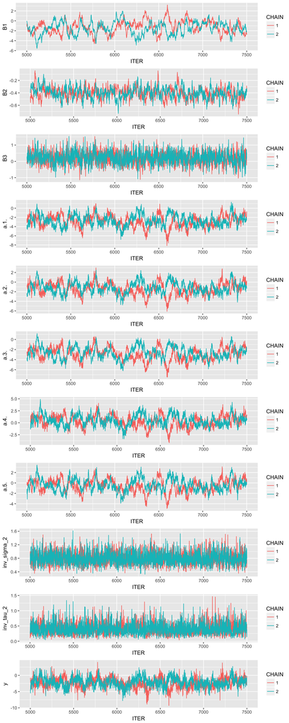

```r
do.call( grid.arrange, c( p, list("ncol" = 1) ) )
```

The initial values can be found in the code above. The number of iterations for tuning and burn-in were set to 5000. Two chains ran for an additional 2,500 iterations each. The trace plots above show both chains apear to be sampling from the same distributions, thus providing evidence the algorithm converged.

Question 3)

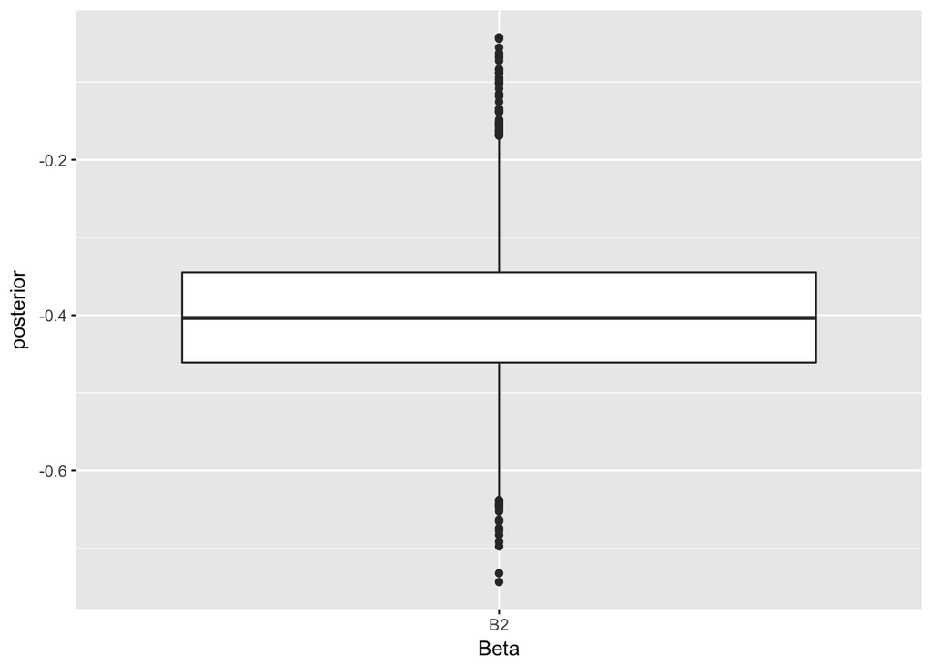

```r
#For part a
postDFreshape <- melt( mcmcChainDF,
                       id.vars = "ITER",
                       measure.vars = c("B2"))
ggplot(postDFreshape,
       aes(x = variable, y = value )) +
  geom_boxplot() +
  scale_x_discrete( labels = c( "B2" )) +
  ylab( "posterior" ) +
  xlab( "Beta" )
```

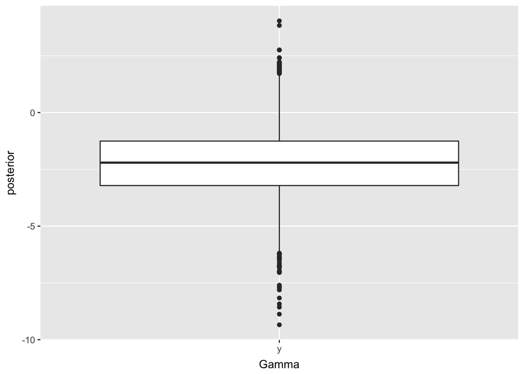

```r
#For part b
postDFreshape <- melt( mcmcChainDF,
                       id.vars = "ITER",
                       measure.vars = c("y"))
ggplot(postDFreshape,
       aes(x = variable, y = value )) +
  geom_boxplot() +
  scale_x_discrete( labels = c( "y" )) +
  ylab( "posterior" ) +
  xlab( "Gamma" )
```

```r
b2 =  mcmcChainDF$B2
mean_b2 = mean(b2)
sd_2_b2 = sd(b2)

mean_b2 + sd_2_b2 * qnorm(.95)
```

```
## [1] -0.2544809
```

```r
mean_b2 - sd_2_b2 * qnorm(.95)
```

```
## [1] -0.549949
```

```r
y =  mcmcChainDF$y
mean_y = mean(y)
sd_2_y = sd(y)

mean_y + sd_2_y * qnorm(.95)
```

```
## [1] 0.309969
```

```r
mean_y - sd_2_y * qnorm(.95)
```

```
## [1] -4.774997
```

1. Is a higher dose of hydroxyurea associated with a greater reduction in packed cell volume?

2. Controlling for the dose of hydroxyurea administered and the type of erythrocytosis, do domestic breeds of cats have a different expected change in pack cell volume than non-domestic cats?